# Raw XY Data (study2children)

Adam Stone, PhD

04-19-2018

# Participants

```r
# Libraries
library(tidyverse)
library(feather)
library(lme4)
library(grid)
library(png)
library(lmerTest)
#library(cowplot)
# Import data (and fix one participant name, and fix Owen as EnglishExposed)
data <- read_feather("../Child Data/childxydata.feather")
# Get ages
ages <- read_csv("childrenages.csv")
data <- data %>% left_join(ages, by = "participant")
data %>% select(participant,language,age) %>% distinct() %>% arrange(age)  # print data table
```

| participant | language | age |
| --- | --- | --- |
| AsherCalibOnly | EnglishExposed | 0.00 |
| AB11Mi20_5M_10D | EnglishExposed | 0.40 |
| Li11hy29_5m_M | EnglishExposed | 0.40 |
| NI12GO05_5M_4D | EnglishExposed | 0.40 |
| Brooke CODA | SignLanguageExposed | 0.40 |
| an06he01_6m | EnglishExposed | 0.50 |
| ca05he16_6m | EnglishExposed | 0.50 |
| desmond | EnglishExposed | 0.50 |
| do09ne07_6m_4d | EnglishExposed | 0.50 |
| DY10PE27_6m_11d_m | EnglishExposed | 0.50 |

[output cut: 71 more lines]

## Removing Excluded Kids

I excluded all kids that were not included in the AOI analysis. Here is a list of all of ’em!

```r
# Load included babies and children lists
included_babies <- read_feather("cleanedbabyeyedata.feather") %>%
  select(participant) %>%
  distinct()
included_children <- read_feather("cleanedchildeyedata.feather") %>%
  select(participant) %>%
  distinct()
included <- rbind(included_babies, included_children)
# Use antijoin to see excluded kids
excluded <- anti_join(data, included, by = "participant") %>%
  select(participant, language, age) %>%
  distinct()
# Print table
excluded
```

| participant | language | age |
| --- | --- | --- |
| AsherCalibOnly | EnglishExposed | 0.00 |
| do09ne07_6m_4d | EnglishExposed | 0.50 |
| Em12ad10_14m_24d | EnglishExposed | 1.20 |
| Gianna_CODA_18m | SignLanguageExposed | 1.50 |
| Gianni 3y6m CODA | SignLanguageExposed | 3.55 |
| Isabella 5 year old Deaf | SignLanguageExposed | 5.00 |
| JelenaCODAhearing_4y2m | SignLanguageExposed | 4.20 |
| ka11es12_7m_MomTerp | SignLanguageExposed | 0.60 |
| Li11hy29_5m_M | EnglishExposed | 0.40 |
| lo08jo20_6m_14d | EnglishExposed | 0.50 |

[output cut: 7 more lines]

```r
# Remove excluded kids from main dataset
data <- semi_join(data, included, by = "participant")
```

## Participant Tables and Charts

Let’s see a histogram of ages! After this I’ll add “baby” and “child” variables so all < 2.0 are identified as babies.

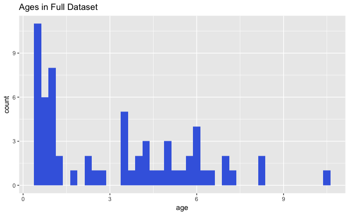

```r
# Histogram of ages
data %>% select(participant,language,age) %>%
  distinct() %>%
  ggplot(aes(x = age)) + geom_histogram(fill = "royalblue", binwidth = 0.25) + ggtitle("Ages in Full Dataset")
```

```r
# Add baby/child agegroup column
data <- data %>%
  mutate(agegroup = age < 2.0)
data$agegroup <- as.factor(data$agegroup)
data$agegroup <- fct_recode(data$agegroup, baby = "TRUE", child = "FALSE")
```

And our participant table.

```r
participants_b <- data %>%
  filter(agegroup=="baby") %>%
  select(participant, gender, language, age) %>%
  distinct()
participants_b_n <- participants_b %>%
  count(gender, language) %>%
  spread(gender, n)
participants_b_age <- participants_b %>%
  group_by(language) %>%
  summarise(age_m = round(mean(age), 1),
            age_sd = round(sd(age), 1),
            age_min = range(age)[1],
            age_max = range(age)[2]) %>%
  mutate(age_range = paste(age_min, age_max, sep = " - ")) %>%
  select(-age_min, -age_max) %>%
  mutate(age_mean = paste(age_m, age_sd, sep = "±")) %>%
  select(-age_m, -age_sd) %>%
  select(language, age_mean, age_range)
participants_table_b <- left_join(participants_b_n, participants_b_age, by = "language") %>%
  add_column(agegroup = "baby")
participants_c <- data %>%
  filter(agegroup=="child") %>%
  select(participant, gender, language, age) %>%
  distinct()
participants_c_n <- participants_c %>%
  count(gender, language) %>%
  spread(gender, n)
participants_c_age <- participants_c %>%
  group_by(language) %>%
  summarise(age_m = round(mean(age), 1),
            age_sd = round(sd(age), 1),
            age_min = range(age)[1],
            age_max = range(age)[2]) %>%
  mutate(age_range = paste(age_min, age_max, sep = " - ")) %>%
  select(-age_min, -age_max) %>%
  mutate(age_mean = paste(age_m, age_sd, sep = "±")) %>%
  select(-age_m, -age_sd) %>%
  select(language, age_mean, age_range)
participants_table_c <- left_join(participants_c_n, participants_c_age, by = "language") %>%
  add_column(agegroup = "child")
rbind(participants_table_b, participants_table_c) %>%
  select(language, agegroup, Female, Male, age_mean, age_range)
```

| language | agegroup | Female | Male | age_mean | age_range |
| --- | --- | --- | --- | --- | --- |
| EnglishExposed | baby | 5 | 11 | 0.7±0.2 | 0.4 - 1.1 |
| SignLanguageExposed | baby | 8 | 4 | 0.9±0.4 | 0.6 - 1.87 |
| EnglishExposed | child | 8 | 7 | 5±1.4 | 2.7 - 8.3 |
| SignLanguageExposed | child | 10 | 11 | 5.2±2.1 | 2.13 - 10.5 |

## Save!

Great. Let’s save this as `cleanedchildxydata.csv’.

```r
# Pull apart condition columns
data <- data %>%
  separate(condition, into = c("story", "clipnum", "direction", "media"), sep = "_") %>%
  unite(story, clipnum, col = "story", sep = "_") %>%
  select(-media)
# A bit more cleaning up
data <- data %>%
  mutate(direction = case_when(
    direction == "FW" ~ "forward",
    direction == "ER" ~ "reversed"
  )) %>%
  mutate(language = case_when(
    language == "SignLanguageExposed" ~ "SE",
    language == "EnglishExposed" ~ "NSE"
  )) %>%
  mutate(group = as.factor(group),
         gender = as.factor(gender),
         language = as.factor(language),
         story = as.factor(story),
         direction = as.factor(direction))
# Save as csv and feather (feather preserves column types for R)
write_csv(data,"../Child Data/cleanedchildxydata.csv")
write_feather(data,"../Child Data/cleanedchildxydata.feather")
```

## Any other data cleanup??

Do we need to do any other cleanup? I don’t think so.

# Means vs Medians

First, let’s trim each participant’s data, getting rid of the first 60 samples (0.5 secs). Then we’ll get the the mean x and y coordinate for each story for each participant.

```r
# Just to load data again
data <- read_feather("../Child Data/cleanedchildxydata.feather")
data <- data %>%
  group_by(participant,trial) %>%
  slice(60:n())
data_central_tendencies <- data %>%
  group_by(language, agegroup, participant, trial) %>%
  summarise(mean_x = mean(x,na.rm=TRUE),
            mean_y = mean(y,na.rm=TRUE),
            median_x = median(x, na.rm=TRUE),
            median_y = median(y, na.rm=TRUE),
            diff_x = mean_x - median_x,
            diff_y = mean_y - median_y)
means <- data_central_tendencies %>%
  group_by(language, agegroup, participant) %>%
  summarise(mean_x = mean(mean_x, na.rm = TRUE),
            mean_y = mean(mean_y, na.rm = TRUE)) %>%
  group_by(language, agegroup) %>%
  summarise(sd_x = sd(mean_x),
            sd_y = sd(mean_y),
            n = n(),
            mean_x = mean(mean_x),
            mean_y = mean(mean_y)*-1,
            se_x = sd_x/sqrt(n),
            se_y = sd_y/sqrt(n))
means
```

| language | agegroup | sd_x | sd_y | n | mean_x | mean_y | se_x | se_y |
| --- | --- | --- | --- | --- | --- | --- | --- | --- |
| NSE | child | 19.72372 | 35.10913 | 15 | 524.2828 | -310.0131 | 5.092643 | 9.065138 |
| NSE | baby | 20.17806 | 31.56338 | 16 | 533.9185 | -337.6371 | 5.044514 | 7.890845 |
| SE | child | 14.71279 | 30.19302 | 21 | 530.7693 | -296.2221 | 3.210593 | 6.588656 |
| SE | baby | 33.30225 | 36.64919 | 12 | 532.3291 | -318.4772 | 9.613531 | 10.579709 |

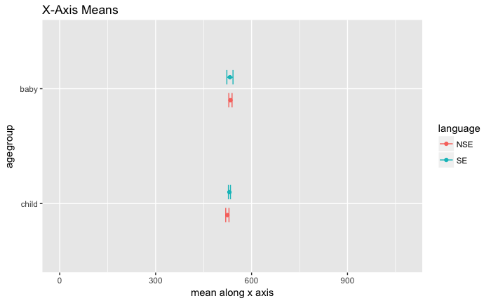

```r
means_error <- means %>%
  select(-n, -sd_x, -sd_y) %>%
  gather(measure, value, mean_x:se_y) %>%
  separate(measure, into = c("measure","axis")) %>%
  spread(measure, value)
means_error %>%
  filter(axis == "x") %>%
  ggplot(aes(x = agegroup, y = mean, color = language, group = language)) +
  geom_point(position = position_dodge(width = 0.4)) +
  geom_errorbar(aes(ymin = mean-se, ymax = mean+se),
                position = position_dodge(width = 0.4), width = 0.25, size = 0.5) +
  scale_y_continuous(limits = c(0,1080)) +
  coord_flip() +
  labs(y = "mean along x axis", title = "X-Axis Means")
```

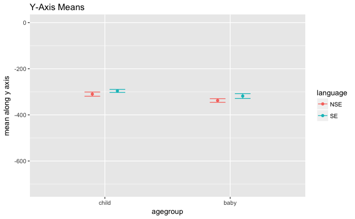

```r
means_error %>%
  filter(axis == "y") %>%
  ggplot(aes(x = agegroup, y = mean, color = language, group = language)) +
  geom_point(position = position_dodge(width = 0.4)) +
  geom_errorbar(aes(ymin = mean-se, ymax = mean+se),
                position = position_dodge(width = 0.4), width = 0.25, size = 0.5) +
  scale_y_continuous(limits = c(-720,0)) +
  labs(y = "mean along y axis", title = "Y-Axis Means")
```

## Distribution

But is the y-value distribution unimodal, bimodal, normal, what? Do the means represent the only peak? Let’s get histograms.

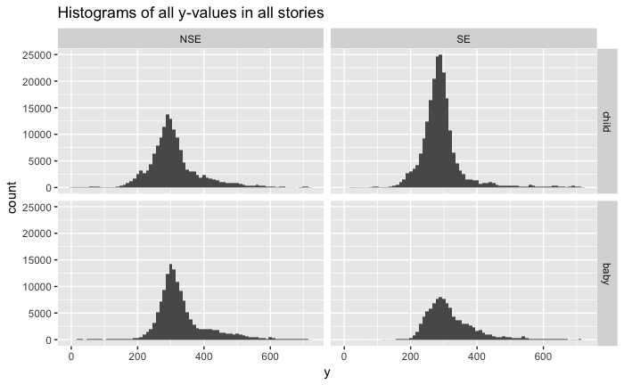

```r
ggplot(data, aes(x = y)) + geom_histogram(binwidth = 10) + facet_grid(agegroup ~ language) +
  ggtitle("Histograms of all y-values in all stories")
```

Maybe the mixture of stories and directions throws off the histograms. Let’s break it down by “mark” which is an unique number I assigned to each story/direction. Below is a “guide” for each mark.

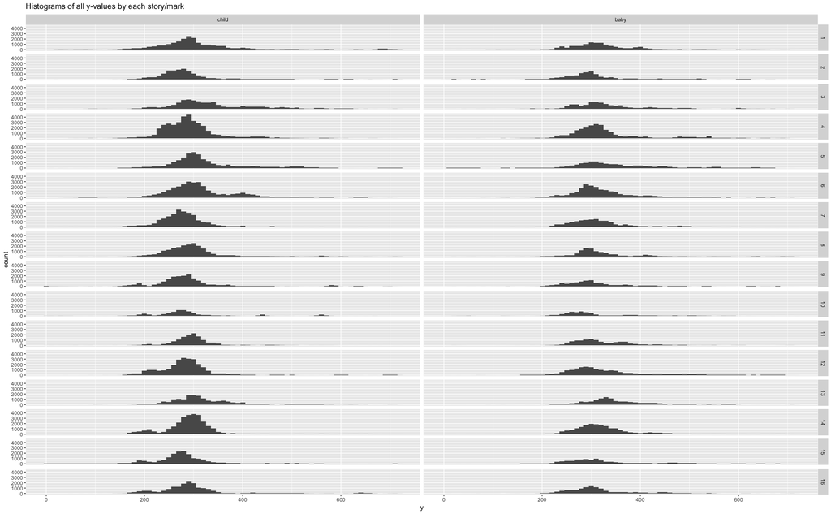

```r
ggplot(data, aes(x = y)) + geom_histogram(binwidth = 10) + facet_grid(mark ~ agegroup) +
  ggtitle("Histograms of all y-values by each story/mark")
```

```r
data %>% ungroup() %>% select(mark, story, direction) %>% distinct() %>% arrange(mark)
```

| mark | story | direction |
| --- | --- | --- |
| 1 | Cinderella_1 | forward |
| 2 | Cinderella_2 | forward |
| 3 | ThreeBears_1 | reversed |
| 4 | ThreeBears_2 | reversed |
| 5 | KingMidas_1 | reversed |
| 6 | KingMidas_2 | reversed |
| 7 | RedRiding_1 | forward |
| 8 | RedRiding_2 | forward |
| 9 | Cinderella_1 | reversed |
| 10 | Cinderella_2 | reversed |

[output cut: 6 more lines]

Still seems mostly unimodal (that means one peak, right?).

## Skewness

But is the data skewed? I’ve been wondering if we should be using MEDIANS because there can be some extreme x and y values. But Rain said there’s been criticism of using medians and that means are better overall. Let’s have a look.

The first chart shows the difference between the mean and the median for each participant and trial. Positive means the mean is bigger than the median, negative means the median is bigger. It shows there is some skew for the y-axis…but the vast majority of differences is less than 50 px so maybe it’s okay.

The second chart shows the means and medians themselves. And the spread is pretty similar between mean and median so maybe using means is fine.

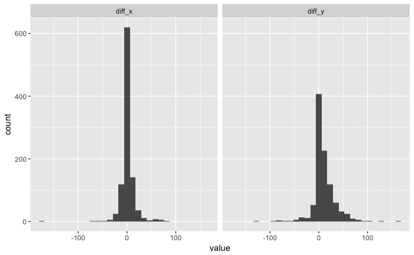

```r
data_central_tendencies %>%
  gather(measure, value, diff_x:diff_y) %>%
  ggplot(aes(x = value)) + geom_histogram() + facet_grid(. ~ measure)
```

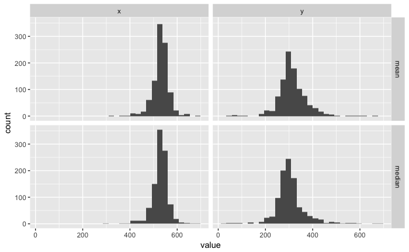

```r
data_central_tendencies %>%
  gather(measure, value, mean_x:median_y) %>%
  separate(measure, into = c("measure","axis")) %>%
  ggplot(aes(x = value)) + geom_histogram() + facet_grid(measure ~ axis)
```

## Testing the Means

Let’s run a LMM on the means. First, x means for babies.

```r
means <- data %>%
  group_by(language, agegroup, participant, age, story, direction, trial, repetition) %>%
  summarise(x = mean(x, na.rm = TRUE),
            y = mean(y, na.rm = TRUE))
means$repetition = as.factor(means$repetition)
means$trial = as.factor(means$trial)
lmm_baby_mean_x <- lmer(x ~ language * direction + age +
                          (1|story) + (1|participant) + (1|repetition) + (1|trial),
                        data = filter(means, agegroup == "baby"))
summary(lmm_baby_mean_x)
```

```
Linear mixed model fit by REML t-tests use Satterthwaite approximations to degrees of freedom [
lmerMod]
Formula: x ~ language * direction + age + (1 | story) + (1 | participant) +
    (1 | repetition) + (1 | trial)
   Data: filter(means, agegroup == "baby")

REML criterion at convergence: 4091.1

Scaled residuals:
    Min      1Q  Median      3Q     Max
-4.6447 -0.4455  0.0216  0.4952  3.5964

Random effects:
 Groups      Name        Variance  Std.Dev.
 participant (Intercept) 6.914e+02 2.629e+01
 trial       (Intercept) 1.483e+01 3.852e+00
 story       (Intercept) 6.060e+01 7.785e+00
 repetition  (Intercept) 9.096e-14 3.016e-07
 Residual                7.018e+02 2.649e+01
Number of obs: 429, groups:  participant, 28; trial, 16; story, 8; repetition, 2

Fixed effects:
                             Estimate Std. Error      df t value Pr(>|t|)
(Intercept)                   529.988     13.940  28.100  38.019   <2e-16 ***
languageSE                     -1.961     11.383  27.800  -0.172    0.864
directionreversed               2.125      3.712  94.100   0.572    0.568
age                             4.344     16.991  25.000   0.256    0.800
languageSE:directionreversed   -1.505      5.174 380.700  -0.291    0.771
---
Signif. codes:  0 ‘***’ 0.001 ‘**’ 0.01 ‘*’ 0.05 ‘.’ 0.1 ‘ ’ 1

Correlation of Fixed Effects:
            (Intr) lnggSE drctnr age
languageSE  -0.018
dirctnrvrsd -0.127  0.133
age         -0.838 -0.346 -0.002
lnggSE:drct  0.078 -0.225 -0.607  0.000
```

Y means for babies

```r
lmm_baby_mean_y <- lmer(y ~ language * direction + age +
                          (1|story) + (1|participant) + (1|repetition) + (1|trial),
                        data = filter(means, agegroup == "baby"))
summary(lmm_baby_mean_y)
```

```
Linear mixed model fit by REML t-tests use Satterthwaite approximations to degrees of freedom [
lmerMod]
Formula: y ~ language * direction + age + (1 | story) + (1 | participant) +
    (1 | repetition) + (1 | trial)
   Data: filter(means, agegroup == "baby")

REML criterion at convergence: 4472.2

Scaled residuals:
    Min      1Q  Median      3Q     Max
-4.7629 -0.5152 -0.0865  0.3686  7.5235

Random effects:
 Groups      Name        Variance Std.Dev.
 participant (Intercept)  987.93  31.431
 trial       (Intercept)    0.00   0.000
 story       (Intercept)  156.15  12.496
 repetition  (Intercept)   54.43   7.378
 Residual                1793.08  42.345
Number of obs: 429, groups:  participant, 28; trial, 16; story, 8; repetition, 2

Fixed effects:
                             Estimate Std. Error      df t value Pr(>|t|)
(Intercept)                   359.035     18.093  26.500  19.844   <2e-16 ***
languageSE                    -11.917     14.183  29.700  -0.840    0.408
directionreversed              -5.524      5.497 394.300  -1.005    0.315
age                           -27.485     20.794  24.900  -1.322    0.198
languageSE:directionreversed   -1.133      8.269 391.400  -0.137    0.891
---
Signif. codes:  0 ‘***’ 0.001 ‘**’ 0.01 ‘*’ 0.05 ‘.’ 0.1 ‘ ’ 1

Correlation of Fixed Effects:
            (Intr) lnggSE drctnr age
languageSE  -0.028
dirctnrvrsd -0.144  0.185
age         -0.790 -0.339 -0.003
lnggSE:drct  0.096 -0.289 -0.656  0.000
```

X means for children

```r
lmm_child_mean_x <- lmer(x ~ language * direction + age +
                          (1|story) + (1|participant) + (1|repetition) + (1|trial),
                        data = filter(means, agegroup == "child"))
summary(lmm_child_mean_x)
```

```
Linear mixed model fit by REML t-tests use Satterthwaite approximations to degrees of freedom [
lmerMod]
Formula: x ~ language * direction + age + (1 | story) + (1 | participant) +
    (1 | repetition) + (1 | trial)
   Data: filter(means, agegroup == "child")

REML criterion at convergence: 5205.9

Scaled residuals:
    Min      1Q  Median      3Q     Max
-6.5624 -0.4214 -0.0220  0.4497  5.6293

Random effects:
 Groups      Name        Variance  Std.Dev.
 participant (Intercept) 2.444e+02 15.63444
 trial       (Intercept) 8.803e-04  0.02967
 story       (Intercept) 2.706e+01  5.20181
 repetition  (Intercept) 1.265e+01  3.55607
 Residual                6.995e+02 26.44827
Number of obs: 549, groups:  participant, 36; trial, 16; story, 8; repetition, 2

Fixed effects:
                             Estimate Std. Error       df t value Pr(>|t|)
(Intercept)                  517.4405     9.7123  34.1000  53.277   <2e-16 ***
languageSE                     5.8790     6.2237  44.7000   0.945    0.350
directionreversed             -0.3100     3.5974 138.7000  -0.086    0.931
age                            1.4262     1.5807  33.1000   0.902    0.373
languageSE:directionreversed   0.5937     4.6868 500.5000   0.127    0.899
---
Signif. codes:  0 ‘***’ 0.001 ‘**’ 0.01 ‘*’ 0.05 ‘.’ 0.1 ‘ ’ 1

Correlation of Fixed Effects:
            (Intr) lnggSE drctnr age
languageSE  -0.332
dirctnrvrsd -0.185  0.294
age         -0.811 -0.052 -0.002
lnggSE:drct  0.141 -0.375 -0.772  0.004
```

Y means for children

```r
lmm_child_mean_y <- lmer(y ~ language * direction + age +
                          (1|story) + (1|participant) + (1|repetition) + (1|trial),
                        data = filter(means, agegroup == "child"))
summary(lmm_child_mean_y)
```

```
Linear mixed model fit by REML t-tests use Satterthwaite approximations to degrees of freedom [
lmerMod]
Formula: y ~ language * direction + age + (1 | story) + (1 | participant) +
    (1 | repetition) + (1 | trial)
   Data: filter(means, agegroup == "child")

REML criterion at convergence: 5906.3

Scaled residuals:
    Min      1Q  Median      3Q     Max
-4.9767 -0.4291 -0.0869  0.3004  5.7854

Random effects:
 Groups      Name        Variance Std.Dev.
 participant (Intercept)  873.4   29.55
 trial       (Intercept)    0.0    0.00
 story       (Intercept)  208.7   14.45
 repetition  (Intercept)  141.2   11.88
 Residual                2510.9   50.11
Number of obs: 549, groups:  participant, 36; trial, 16; story, 8; repetition, 2

Fixed effects:
                             Estimate Std. Error      df t value Pr(>|t|)
(Intercept)                   318.319     19.986  19.100  15.927 1.82e-12 ***
languageSE                    -13.635     11.779  44.500  -1.158    0.253
directionreversed               6.127      6.856 510.700   0.894    0.372
age                            -2.228      2.989  32.900  -0.745    0.461
languageSE:directionreversed    1.717      8.917 510.300   0.193    0.847
---
Signif. codes:  0 ‘***’ 0.001 ‘**’ 0.01 ‘*’ 0.05 ‘.’ 0.1 ‘ ’ 1

Correlation of Fixed Effects:
            (Intr) lnggSE drctnr age
languageSE  -0.306
dirctnrvrsd -0.172  0.296
age         -0.745 -0.052 -0.002
lnggSE:drct  0.131 -0.377 -0.774  0.004
```

Let’s try it with both kids and babies.

```r
lmm_all_mean_x <- lmer(x ~ language * direction * agegroup +
                          (1|story) + (1|participant) + (1|repetition) + (1|trial),
                        data = means)
summary(lmm_all_mean_x)
```

```
Linear mixed model fit by REML t-tests use Satterthwaite approximations to degrees of freedom [
lmerMod]
Formula: x ~ language * direction * agegroup + (1 | story) + (1 | participant) +
    (1 | repetition) + (1 | trial)
   Data: means

REML criterion at convergence: 9313.6

Scaled residuals:
    Min      1Q  Median      3Q     Max
-6.4272 -0.4439 -0.0096  0.4477  5.5399

Random effects:
 Groups      Name        Variance Std.Dev.
 participant (Intercept) 426.340  20.648
 trial       (Intercept)  10.925   3.305
 story       (Intercept)  33.390   5.778
 repetition  (Intercept)   6.443   2.538
 Residual                704.356  26.540
Number of obs: 978, groups:  participant, 64; trial, 16; story, 8; repetition, 2

Fixed effects:
                                          Estimate Std. Error       df t value Pr(>|t|)
(Intercept)                               524.0869     6.5677  46.4000  79.798   <2e-16 ***
languageSE                                  6.7436     7.7079  72.8000   0.875    0.385
directionreversed                           0.5448     3.7561 338.1000   0.145    0.885
agegroupbaby                                9.2400     8.1821  72.4000   1.129    0.263
languageSE:directionreversed               -0.6805     4.6674 899.1000  -0.146    0.884
languageSE:agegroupbaby                    -7.6835    11.6152  72.5000  -0.661    0.510
directionreversed:agegroupbaby              0.9396     4.9073 895.3000   0.191    0.848
languageSE:directionreversed:agegroupbaby  -0.8171     6.9707 896.1000  -0.117    0.907
---
Signif. codes:  0 ‘***’ 0.001 ‘**’ 0.01 ‘*’ 0.05 ‘.’ 0.1 ‘ ’ 1

Correlation of Fixed Effects:
            (Intr) lnggSE drctnr aggrpb lnggSE:d lnggSE:g drctn:
languageSE  -0.686
dirctnrvrsd -0.288  0.223
agegroupbby -0.645  0.550  0.207
lnggSE:drct  0.211 -0.301 -0.730 -0.167
lnggSE:ggrp  0.455 -0.664 -0.148 -0.705  0.200
drctnrvrsd:  0.197 -0.168 -0.681 -0.297  0.549    0.210
lnggSE:drc: -0.141  0.202  0.488  0.211 -0.669   -0.298   -0.708
```

```r
lmm_all_mean_y <- lmer(y ~ language * direction * agegroup +
                          (1|story) + (1|participant) + (1|repetition) + (1|trial),
                        data = means)
summary(lmm_all_mean_y)
```

```
Linear mixed model fit by REML t-tests use Satterthwaite approximations to degrees of freedom [
lmerMod]
Formula: y ~ language * direction * agegroup + (1 | story) + (1 | participant) +
    (1 | repetition) + (1 | trial)
   Data: means

REML criterion at convergence: 10397.5

Scaled residuals:
    Min      1Q  Median      3Q     Max
-5.3388 -0.4505 -0.1106  0.3424  6.7352

Random effects:
 Groups      Name        Variance  Std.Dev.
 participant (Intercept) 9.301e+02 3.050e+01
 trial       (Intercept) 1.996e-13 4.468e-07
 story       (Intercept) 1.801e+02 1.342e+01
 repetition  (Intercept) 1.020e+02 1.010e+01
 Residual                2.202e+03 4.692e+01
Number of obs: 978, groups:  participant, 64; trial, 16; story, 8; repetition, 2

Fixed effects:
                                          Estimate Std. Error      df t value Pr(>|t|)
(Intercept)                                307.645     12.460   8.000  24.692  7.7e-09 ***
languageSE                                 -14.666     11.821  77.400  -1.241   0.2185
directionreversed                            5.267      6.320 909.300   0.833   0.4049
agegroupbaby                                32.579     12.541  76.800   2.598   0.0112 *
languageSE:directionreversed                 2.604      8.259 908.100   0.315   0.7526
languageSE:agegroupbaby                     -3.402     17.805  77.000  -0.191   0.8490
directionreversed:agegroupbaby             -10.804      8.677 905.100  -1.245   0.2134
languageSE:directionreversed:agegroupbaby   -4.238     12.328 905.400  -0.344   0.7311
---
Signif. codes:  0 ‘***’ 0.001 ‘**’ 0.01 ‘*’ 0.05 ‘.’ 0.1 ‘ ’ 1

Correlation of Fixed Effects:
            (Intr) lnggSE drctnr aggrpb lnggSE:d lnggSE:g drctn:
languageSE  -0.555
dirctnrvrsd -0.256  0.271
agegroupbby -0.522  0.551  0.251
lnggSE:drct  0.197 -0.348 -0.769 -0.193
lnggSE:ggrp  0.369 -0.664 -0.180 -0.705  0.231
drctnrvrsd:  0.183 -0.194 -0.715 -0.343  0.549    0.243
lnggSE:drc: -0.132  0.233  0.514  0.243 -0.669   -0.344   -0.708
```

## Summary

No difference in the mean looking position for x or y in children or babies! But if we put children and babies in the same dataset we get a significant main effect of children vs. babies. Okay.

# Plotting One Kid

And I can get x or y plots of one participant across 8 stories. Let’s do Emmet. We’ll set the x and y limits to the whole width of the Tobii monitor (1600x1200…or is it now 1080x720). But because Tobii considers (0,0) to be the upper left corner (and not the bottom left corner), we also need to flip the y axis.

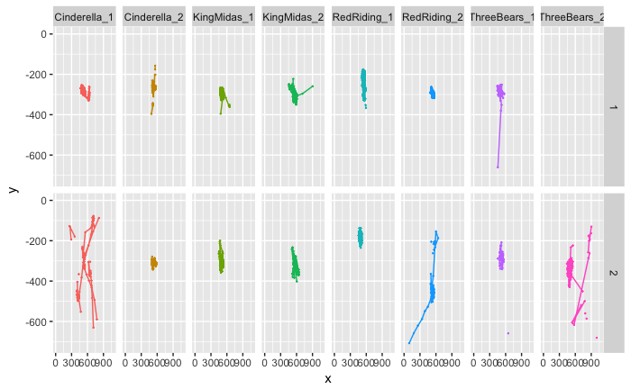

```r
emmet <- filter(data,participant=="emmet_12_10_12_CODA") %>% mutate(y = y*-1)
ggplot(emmet,aes(x=x,y=y,color=story)) + geom_point(size=0.1) + geom_path() + facet_grid(repetition ~ story) + guides(color="none") + scale_x_continuous(limit=c(0,1080)) + scale_y_continuous(limit=c(-720,0))
```

Cool, yeah?

# Viewing Space (SD)

To measure viewing space, we can use standard deviation or IQR. Generally, if we’re using means, we should use standard deviations. If we’re using medians, we should use IQR. That’s my thinking, anyway.

We’ll try SDs first. Let’s try the first SD, which is the middle 68% of the data.

```r
sd <- data %>%
  group_by(participant, trial) %>%
  summarise(mean_x = mean(x, na.rm = TRUE),
            mean_y = mean(y, na.rm = TRUE),
            sd_x = sd(x, na.rm = TRUE),
            sd_y = sd(y, na.rm = TRUE)) %>%
  ungroup()
head(sd,10)
```

| participant | trial | mean_x | mean_y | sd_x | sd_y |
| --- | --- | --- | --- | --- | --- |
| Ab07ov09_32m | 1 | 518.2213 | 318.4398 | 46.934081 | 84.95017 |
| Ab07ov09_32m | 2 | 515.2019 | 269.2530 | 28.049879 | 28.49894 |
| Ab07ov09_32m | 3 | 520.0502 | 286.6715 | 43.306736 | 122.88163 |
| Ab07ov09_32m | 4 | 542.0149 | 298.3843 | 11.276873 | 22.78948 |
| Ab07ov09_32m | 5 | 548.4278 | 318.3076 | 30.244741 | 24.91901 |
| Ab07ov09_32m | 6 | 553.1987 | 251.1674 | 32.820620 | 23.13304 |
| Ab07ov09_32m | 7 | 506.2269 | 391.8369 | 54.026776 | 167.55785 |
| Ab07ov09_32m | 8 | 557.8473 | 298.3606 | 43.751664 | 70.89762 |
| Ab07ov09_32m | 9 | 566.5259 | 356.7556 | 9.304813 | 28.26249 |
| Ab07ov09_32m | 10 | 518.2249 | 342.4257 | 81.498600 | 48.83055 |

```r
# join participant info back
participantinfo <- data %>%
  select(participant, trial, age, group, agegroup, gender, language, story, direction, mark, repetition) %>%
  distinct()
sd <- left_join(sd, participantinfo, by = c("participant","trial"))
```

And check out the histograms. I truncated the y-axis at 50 counts to better see outliers.

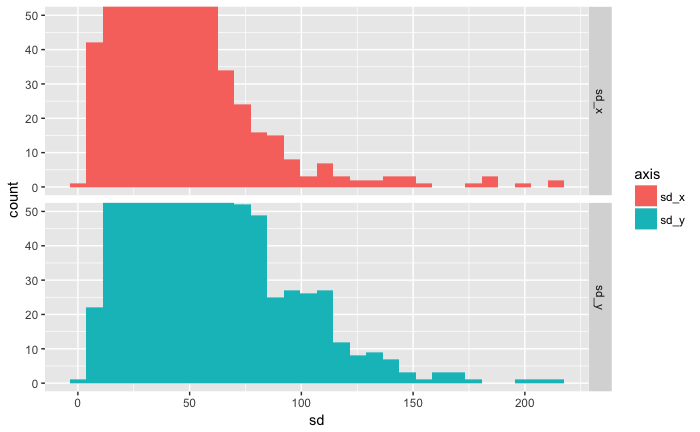

```r
sd %>%
  gather(axis,sd,sd_x:sd_y) %>%
  ggplot(aes(x=sd,fill=axis)) + geom_histogram() + facet_grid(axis~.) +
  coord_cartesian(ylim = c(0,50))
```

So there are some really high outliers where the SD is 150 or 200 pixels in one direction (so a spread of as high as 400 pixels, which is a lot! I want to see those cases to see if they should be taken out or if we don’t need to worry about them.

> It may be useful to think about getting rid of outliers. We should keep this in mind…

```r
xoutliers <- sd %>%
  arrange(desc(sd_x)) %>%
  slice(1:20)
youtliers <- sd %>%
  arrange(desc(sd_y)) %>%
  slice(1:20)
xoutliers
```

| participant | trial | mean_x | mean_y | sd_x | sd_y | age | group | agegroup | gender | language | story | direction | mark | repetition |
| --- | --- | --- | --- | --- | --- | --- | --- | --- | --- | --- | --- | --- | --- | --- |
| Olivia CODA 2.5 y | 7 | 324.6113 | 314.4415 | 214.5495 | 65.64053 | 2.52 | 1 | child | Female | SE | KingMidas_1 | reversed | 5 | 1 |
| CR03TA11_12M_29D | 2 | 492.1162 | 310.8920 | 213.9505 | 48.43502 | 1.10 | 1 | baby | Male | NSE | RedRiding_1 | forward | 7 | 1 |
| AB11Mi20_5M_10D | 13 | 592.3858 | 426.9055 | 196.9746 | 159.19141 | 0.40 | 1 | baby | Female | NSE | Cinderella_1 | forward | 1 | 2 |
| JuliaCoda | 8 | 574.8262 | 418.1368 | 187.4382 | 128.92804 | 5.00 | 2 | child | Female | SE | RedRiding_1 | reversed | 15 | 1 |
| Hannah_CODA_7m | 5 | 594.3442 | 261.7246 | 185.4255 | 34.53857 | 0.60 | 1 | baby | Female | SE | Cinderella_1 | forward | 1 | 1 |
| za05da21_6m_15days_Squirmy | 13 | 642.0609 | 346.8310 | 183.5946 | 41.05205 | 0.50 | 2 | baby | Male | NSE | KingMidas_1 | forward | 13 | 2 |
| Hannah_CODA_7m | 11 | 589.2341 | 287.2238 | 174.7192 | 54.53248 | 0.60 | 1 | baby | Female | SE | ThreeBears_2 | reversed | 4 | 2 |
| Hannah_CODA_7m | 13 | 568.6404 | 289.7778 | 158.4824 | 54.57286 | 0.60 | 1 | baby | Female | SE | Cinderella_1 | forward | 1 | 2 |
| ka11es12_3.5y | 5 | 554.3124 | 279.5770 | 150.4296 | 115.17232 | 3.50 | 1 | child | Female | SE | Cinderella_1 | forward | 1 | 1 |
| OwenTwin030212_4y2m | 8 | 422.9957 | 284.7424 | 146.8307 | 113.59921 | 4.20 | 2 | child | Male | NSE | RedRiding_1 | reversed | 15 | 1 |

[output cut: 10 more lines]

```r
youtliers
```

| participant | trial | mean_x | mean_y | sd_x | sd_y | age | group | agegroup | gender | language | story | direction | mark | repetition |
| --- | --- | --- | --- | --- | --- | --- | --- | --- | --- | --- | --- | --- | --- | --- |
| za02pa_1y11m | 13 | 601.7442 | 401.8372 | 29.947871 | 213.5030 | 1.87 | 1 | baby | Male | SE | Cinderella_1 | forward | 1 | 2 |
| AB11Mi20_5M_10D | 12 | 627.1308 | 438.4579 | 106.456394 | 204.5177 | 0.40 | 1 | baby | Female | NSE | KingMidas_2 | reversed | 6 | 2 |
| za02pa_1y11m | 16 | 516.3879 | 431.6028 | 60.489040 | 196.2415 | 1.87 | 1 | baby | Male | SE | RedRiding_2 | forward | 8 | 2 |
| ma08es19_2011_6year_gril | 4 | 539.0500 | 382.8333 | 25.186950 | 174.7293 | 6.00 | 1 | child | Female | NSE | KingMidas_2 | reversed | 6 | 1 |
| za05da21_6m_15days_Squirmy | 8 | 630.0000 | 193.5000 | 55.305214 | 173.2599 | 0.50 | 2 | baby | Male | NSE | RedRiding_1 | reversed | 15 | 1 |
| Ab07ov09_32m | 7 | 506.2269 | 391.8369 | 54.026776 | 167.5579 | 2.70 | 2 | child | Female | NSE | ThreeBears_2 | forward | 12 | 1 |
| Elizabeth 11_17_11_4y1m | 9 | 520.9877 | 435.6680 | 39.227781 | 167.0653 | 4.10 | 1 | child | Female | NSE | Cinderella_2 | forward | 2 | 2 |
| luca_27m | 3 | 545.2416 | 487.6411 | 13.709602 | 162.2847 | 2.27 | 2 | child | Male | SE | RedRiding_2 | reversed | 16 | 1 |
| JuliaCoda | 15 | 554.8829 | 327.4099 | 30.105167 | 161.4495 | 5.00 | 2 | child | Female | SE | Cinderella_1 | reversed | 9 | 2 |
| AB11Mi20_5M_10D | 13 | 592.3858 | 426.9055 | 196.974589 | 159.1914 | 0.40 | 1 | baby | Female | NSE | Cinderella_1 | forward | 1 | 2 |

[output cut: 10 more lines]

## Testing

First, does reversal and language experience have an effect on the SD? Babies, x-axis first.

```r
sd$trial <- as.factor(sd$trial)
sd$repetition <- as.factor(sd$repetition)
sd_x_baby <- lmer(sd_x ~ direction * language + age + (1|participant) + (1|story) + (1|repetition) + (1|trial), data = filter(sd, agegroup == "baby"))
summary(sd_x_baby)
```

```
Linear mixed model fit by REML t-tests use Satterthwaite approximations to degrees of freedom [
lmerMod]
Formula: sd_x ~ direction * language + age + (1 | participant) + (1 |
    story) + (1 | repetition) + (1 | trial)
   Data: filter(sd, agegroup == "baby")

REML criterion at convergence: 4031.8

Scaled residuals:
    Min      1Q  Median      3Q     Max
-2.1433 -0.5660 -0.1759  0.4209  6.1048

Random effects:
 Groups      Name        Variance Std.Dev.
 participant (Intercept) 128.49   11.335
 trial       (Intercept)   0.00    0.000
 story       (Intercept)  23.15    4.811
 repetition  (Intercept)   0.00    0.000
 Residual                679.40   26.065
Number of obs: 429, groups:  participant, 28; trial, 16; story, 8; repetition, 2

Fixed effects:
                             Estimate Std. Error      df t value Pr(>|t|)
(Intercept)                    58.666      6.950  30.900   8.441 1.58e-09 ***
directionreversed              -1.729      3.374 398.300  -0.512   0.6086
languageSE                     -3.013      5.932  37.500  -0.508   0.6145
age                           -14.763      8.214  25.100  -1.797   0.0844 .
directionreversed:languageSE    1.570      5.087 393.300   0.309   0.7579
---
Signif. codes:  0 ‘***’ 0.001 ‘**’ 0.01 ‘*’ 0.05 ‘.’ 0.1 ‘ ’ 1

Correlation of Fixed Effects:
            (Intr) drctnr lnggSE age
dirctnrvrsd -0.231
languageSE  -0.066  0.273
age         -0.813 -0.004 -0.320
drctnrvr:SE  0.154 -0.656 -0.425  0.000
```

That’s fine, we’re not exactly predicting changes along the x-axis. The y-axis is what we are really interested in! :)

```r
sd_y_baby <- lmer(sd_y ~ direction * language + age + (1|participant) + (1|story) + (1|repetition) + (1|trial), data = filter(sd, agegroup == "baby"))
summary(sd_y_baby)
```

```
Linear mixed model fit by REML t-tests use Satterthwaite approximations to degrees of freedom [
lmerMod]
Formula: sd_y ~ direction * language + age + (1 | participant) + (1 |
    story) + (1 | repetition) + (1 | trial)
   Data: filter(sd, agegroup == "baby")

REML criterion at convergence: 4152.3

Scaled residuals:
    Min      1Q  Median      3Q     Max
-2.1879 -0.6675 -0.1022  0.5334  5.5186

Random effects:
 Groups      Name        Variance Std.Dev.
 participant (Intercept) 171.10   13.081
 trial       (Intercept)   0.00    0.000
 story       (Intercept)  24.35    4.934
 repetition  (Intercept)   0.00    0.000
 Residual                904.93   30.082
Number of obs: 429, groups:  participant, 28; trial, 16; story, 8; repetition, 2

Fixed effects:
                             Estimate Std. Error      df t value Pr(>|t|)
(Intercept)                    74.335      7.970  30.200   9.327 2.14e-10 ***
directionreversed               1.496      3.892 398.600   0.384    0.701
languageSE                    -11.333      6.846  37.200  -1.656    0.106
age                           -13.111      9.479  24.900  -1.383    0.179
directionreversed:languageSE    2.984      5.871 393.000   0.508    0.612
---
Signif. codes:  0 ‘***’ 0.001 ‘**’ 0.01 ‘*’ 0.05 ‘.’ 0.1 ‘ ’ 1

Correlation of Fixed Effects:
            (Intr) drctnr lnggSE age
dirctnrvrsd -0.232
languageSE  -0.067  0.273
age         -0.818 -0.004 -0.320
drctnrvr:SE  0.155 -0.656 -0.425  0.000
```

Now children, x-axis

```r
sd_x_child <- lmer(sd_x ~ direction * language + age + (1|participant) + (1|story) + (1|repetition) + (1|trial), data = filter(sd, agegroup == "child"))
summary(sd_x_child)
```

```
Linear mixed model fit by REML t-tests use Satterthwaite approximations to degrees of freedom [
lmerMod]
Formula: sd_x ~ direction * language + age + (1 | participant) + (1 |
    story) + (1 | repetition) + (1 | trial)
   Data: filter(sd, agegroup == "child")

REML criterion at convergence: 5010.9

Scaled residuals:
    Min      1Q  Median      3Q     Max
-1.4383 -0.5518 -0.2357  0.2077  7.2716

Random effects:
 Groups      Name        Variance Std.Dev.
 participant (Intercept)  26.257   5.124
 trial       (Intercept)   9.714   3.117
 story       (Intercept)   6.717   2.592
 repetition  (Intercept)   0.000   0.000
 Residual                537.606  23.186
Number of obs: 548, groups:  participant, 36; trial, 16; story, 8; repetition, 2

Fixed effects:
                             Estimate Std. Error       df t value Pr(>|t|)
(Intercept)                   40.6900     4.6287  44.2000   8.791 2.93e-11 ***
directionreversed              4.7157     3.3232 161.5000   1.419   0.1578
languageSE                    -2.3699     3.3429  78.2000  -0.709   0.4805
age                           -1.7091     0.7285  32.0000  -2.346   0.0253 *
directionreversed:languageSE  -0.1704     4.0798 488.0000  -0.042   0.9667
---
Signif. codes:  0 ‘***’ 0.001 ‘**’ 0.01 ‘*’ 0.05 ‘.’ 0.1 ‘ ’ 1

Correlation of Fixed Effects:
            (Intr) drctnr lnggSE age
dirctnrvrsd -0.358
languageSE  -0.383  0.443
age         -0.782 -0.003 -0.052
drctnrvr:SE  0.255 -0.724 -0.607  0.007
```

And children, y-axis

```r
sd_y_child <- lmer(sd_y ~ direction * language + age + (1|participant) + (1|story) + (1|repetition) + (1|trial), data = filter(sd, agegroup == "child"))
summary(sd_y_child)
```

```
Linear mixed model fit by REML t-tests use Satterthwaite approximations to degrees of freedom [
lmerMod]
Formula: sd_y ~ direction * language + age + (1 | participant) + (1 |
    story) + (1 | repetition) + (1 | trial)
   Data: filter(sd, agegroup == "child")

REML criterion at convergence: 5241.5

Scaled residuals:
    Min      1Q  Median      3Q     Max
-2.0820 -0.6600 -0.1660  0.4132  4.4915

Random effects:
 Groups      Name        Variance Std.Dev.
 participant (Intercept) 160.2457 12.6588
 trial       (Intercept)   0.1567  0.3958
 story       (Intercept)  16.1688  4.0210
 repetition  (Intercept)   0.0000  0.0000
 Residual                786.8488 28.0508
Number of obs: 548, groups:  participant, 36; trial, 16; story, 8; repetition, 2

Fixed effects:
                             Estimate Std. Error      df t value Pr(>|t|)
(Intercept)                    66.904      8.063  38.700   8.297 4.06e-10 ***
directionreversed               5.329      3.799 149.600   1.403   0.1627
languageSE                    -11.871      5.510  51.500  -2.154   0.0359 *
age                            -3.007      1.351  33.200  -2.226   0.0329 *
directionreversed:languageSE   -2.624      4.951 497.200  -0.530   0.5964
---
Signif. codes:  0 ‘***’ 0.001 ‘**’ 0.01 ‘*’ 0.05 ‘.’ 0.1 ‘ ’ 1

Correlation of Fixed Effects:
            (Intr) drctnr lnggSE age
dirctnrvrsd -0.234
languageSE  -0.356  0.348
age         -0.834 -0.003 -0.052
drctnrvr:SE  0.178 -0.770 -0.447  0.005
```

And now all babies/children, x axis

```r
sd_x_all <- lmer(sd_x ~ direction * language * agegroup + (1|participant) + (1|story) + (1|repetition) + (1|trial), data = sd)
summary(sd_x_all)
```

```
Linear mixed model fit by REML t-tests use Satterthwaite approximations to degrees of freedom [
lmerMod]
Formula: sd_x ~ direction * language * agegroup + (1 | participant) +
    (1 | story) + (1 | repetition) + (1 | trial)
   Data: sd

REML criterion at convergence: 9071.3

Scaled residuals:
    Min      1Q  Median      3Q     Max
-2.1383 -0.5533 -0.2182  0.3173  6.9530

Random effects:
 Groups      Name        Variance  Std.Dev.
 participant (Intercept) 8.249e+01 9.082e+00
 trial       (Intercept) 9.163e+00 3.027e+00
 story       (Intercept) 8.910e+00 2.985e+00
 repetition  (Intercept) 4.824e-12 2.196e-06
 Residual                6.008e+02 2.451e+01
Number of obs: 977, groups:  participant, 64; trial, 16; story, 8; repetition, 2

Fixed effects:
                                          Estimate Std. Error       df t value Pr(>|t|)
(Intercept)                                32.0506     3.5778  87.7000   8.958 5.13e-14 ***
directionreversed                           5.0340     3.4534 377.2000   1.458 0.145755
languageSE                                 -2.8003     4.3013 105.2000  -0.651 0.516442
agegroupbaby                               16.1880     4.5566 103.8000   3.553 0.000575 ***
directionreversed:languageSE               -0.0397     4.2981 899.3000  -0.009 0.992633
directionreversed:agegroupbaby             -6.3681     4.5293 899.4000  -1.406 0.160075
languageSE:agegroupbaby                    -3.5466     6.4723 104.2000  -0.548 0.584888
directionreversed:languageSE:agegroupbaby   1.6496     6.4286 900.0000   0.257 0.797550
---
Signif. codes:  0 ‘***’ 0.001 ‘**’ 0.01 ‘*’ 0.05 ‘.’ 0.1 ‘ ’ 1

Correlation of Fixed Effects:
            (Intr) drctnr lnggSE aggrpb drc:SE drctn: lngSE:
dirctnrvrsd -0.485
languageSE  -0.705  0.366
agegroupbby -0.663  0.341  0.552
drctnrvr:SE  0.354 -0.730 -0.496 -0.275
drctnrvrsd:  0.331 -0.682 -0.275 -0.491  0.548
lnggSE:ggrp  0.469 -0.244 -0.665 -0.705  0.330  0.347
drctnrv:SE: -0.237  0.488  0.332  0.348 -0.668 -0.708 -0.493
```

```r
sd_y_all <- lmer(sd_y*2 ~ direction * language * agegroup + (1|participant) + (1|story) + (1|repetition) + (1|trial), data = sd)
summary(sd_y_all)
```

```
Linear mixed model fit by REML t-tests use Satterthwaite approximations to degrees of freedom [
lmerMod]
Formula: sd_y * 2 ~ direction * language * agegroup + (1 | participant) +
    (1 | story) + (1 | repetition) + (1 | trial)
   Data: sd

REML criterion at convergence: 10753.1

Scaled residuals:
    Min      1Q  Median      3Q     Max
-2.3003 -0.6570 -0.1713  0.4813  5.5326

Random effects:
 Groups      Name        Variance Std.Dev.
 participant (Intercept)  726.90  26.961
 trial       (Intercept)    3.35   1.830
 story       (Intercept)   71.54   8.458
 repetition  (Intercept)    0.00   0.000
 Residual                3359.64  57.962
Number of obs: 977, groups:  participant, 64; trial, 16; story, 8; repetition, 2

Fixed effects:
                                          Estimate Std. Error      df t value Pr(>|t|)
(Intercept)                                103.844      9.362  83.400  11.092   <2e-16 ***
directionreversed                           10.616      7.814 353.900   1.359   0.1752
languageSE                                 -25.070     11.570  91.700  -2.167   0.0329 *
agegroupbaby                                26.766     12.265  90.700   2.182   0.0317 *
directionreversed:languageSE                -5.098     10.174 899.600  -0.501   0.6164
directionreversed:agegroupbaby              -7.518     10.714 897.900  -0.702   0.4830
languageSE:agegroupbaby                     -3.636     17.419  90.900  -0.209   0.8351
directionreversed:languageSE:agegroupbaby   10.923     15.208 898.400   0.718   0.4728
---
Signif. codes:  0 ‘***’ 0.001 ‘**’ 0.01 ‘*’ 0.05 ‘.’ 0.1 ‘ ’ 1

Correlation of Fixed Effects:
            (Intr) drctnr lnggSE aggrpb drc:SE drctn: lngSE:
dirctnrvrsd -0.420
languageSE  -0.724  0.338
agegroupbby -0.681  0.314  0.551
drctnrvr:SE  0.321 -0.764 -0.437 -0.242
drctnrvrsd:  0.299 -0.713 -0.243 -0.432  0.549
lnggSE:ggrp  0.481 -0.225 -0.664 -0.705  0.290  0.305
drctnrv:SE: -0.214  0.510  0.292  0.306 -0.668 -0.708 -0.434
```

## Summary

When we put babies and children together, we see age group differences for sd_x and sd_y, not surprisingly.

# Everything after this needs to be updated.

# Viewing Space (IQR)

Now let’s get the middle 50% (aka the IQR) of x and y for each participant’s story (we’ve already trimmed the first 60 samples). That should also take care of further weird outliers. And we are defining “viewing space” as the IQR of the x and y axis.

```r
iqr <- data %>%
  group_by(participant,trial) %>%
  summarise(xIQR = IQR(x,na.rm=TRUE),
                   yIQR = IQR(y,na.rm=TRUE),
                   xmed = median(x, na.rm=TRUE),
                   ymed = median(y, na.rm=TRUE)) %>%
  ungroup()
head(iqr,10)
```

| participant | trial | xIQR | yIQR | xmed | ymed |
| --- | --- | --- | --- | --- | --- |
| Ab07ov09_32m | 1 | 34.0 | 76.0 | 526.0 | 284 |
| Ab07ov09_32m | 2 | 35.5 | 39.0 | 514.0 | 267 |
| Ab07ov09_32m | 3 | 30.0 | 45.5 | 524.0 | 249 |
| Ab07ov09_32m | 4 | 15.0 | 25.0 | 541.0 | 294 |
| Ab07ov09_32m | 5 | 32.0 | 33.0 | 552.5 | 319 |
| Ab07ov09_32m | 6 | 57.0 | 30.0 | 552.0 | 248 |
| Ab07ov09_32m | 7 | 73.0 | 285.0 | 522.0 | 334 |
| Ab07ov09_32m | 8 | 24.5 | 63.5 | 554.0 | 266 |
| Ab07ov09_32m | 9 | 11.0 | 44.0 | 566.0 | 361 |
| Ab07ov09_32m | 10 | 36.0 | 38.0 | 506.0 | 339 |

```r
# Join participant info back into IQR table
participantinfo <- data %>%
  select(participant, trial, age, group, gender, language, story, direction, mark, repetition) %>%
  distinct()
iqr <- left_join(iqr, participantinfo, by = c("participant","trial"))
```

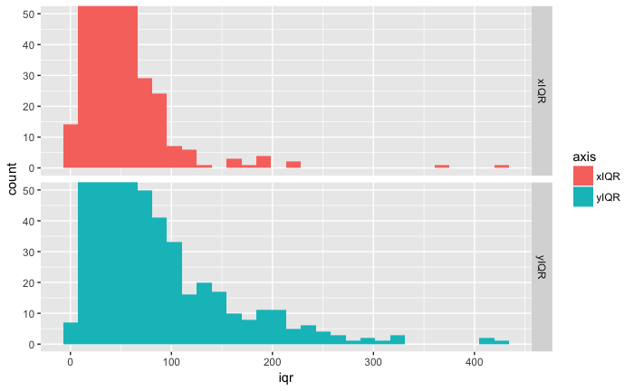

```r
iqr %>%
  gather(axis,iqr,xIQR:yIQR) %>%
  ggplot(aes(x=iqr,fill=axis)) + geom_histogram() + facet_grid(axis~.) +
  coord_cartesian(ylim = c(0,50))
```

So we see some outliers. Who are those? Let’s get a table of them. Review those AFTER I’ve done the cleanups of course.

```r
xoutliers <- iqr %>%
  arrange(desc(xIQR)) %>%
  slice(1:10)
youtliers <- iqr %>%
  arrange(desc(yIQR)) %>%
  slice(1:10)
```

Next, check the medians.

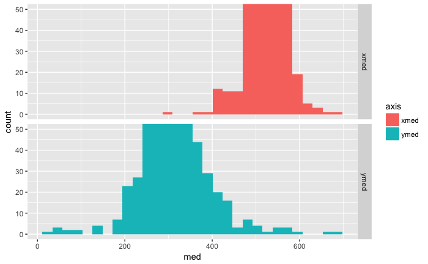

```r
iqr %>%
  gather(axis,med,xmed:ymed) %>%
  ggplot(aes(x=med,fill=axis)) + geom_histogram() + facet_grid(axis~.) +
  coord_cartesian(ylim = c(0,50))
```

SO I need to review those too. After cleaning up/removing kids.

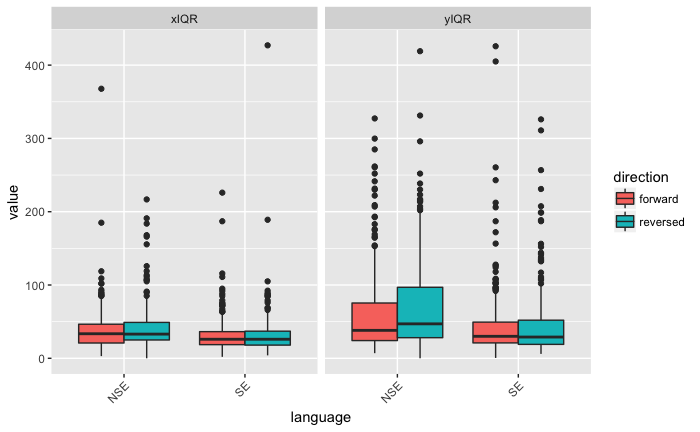

```r
iqr.gather <- iqr %>% gather(axis,value,xIQR:ymed)
iqr.iqr <- filter(iqr.gather,axis=="xIQR" | axis=="yIQR")
iqr.med <- filter(iqr.gather,axis=="xmed" | axis=="ymed")
ggplot(iqr.iqr,aes(x=language,y=value,fill=direction)) +
  geom_boxplot() + theme(axis.text.x=element_text(angle=45,hjust=1)) +
  facet_grid(.~axis)
```

And the median x and y position (this assumes all calibrations are correct):

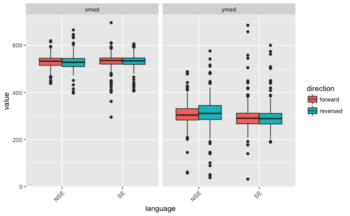

```r
ggplot(iqr.med,aes(x=language,y=value,fill=direction)) +
  geom_boxplot() + theme(axis.text.x=element_text(angle=45,hjust=1)) +
  facet_grid(.~axis)
```

First, does reversal and language experience have an effect on X IQR? We have random intercepts for each participant and media, and a random slope adjustment for reversed for each participant.

```r
xiqr.reversal <- lmer(xIQR ~ direction * language + (direction|participant) + (1|story), data = iqr)
```

[output not shown]

```r
summary(xiqr.reversal)$coefficients
```

[output not shown]

```
                              Estimate Std. Error    t value
(Intercept)                  38.655208   1.886879 20.4863225
directionreversed             3.314929   3.083010  1.0752249
languageSE                   -7.206389   2.631423 -2.7385905
directionreversed:languageSE -1.948684   4.296866 -0.4535129
```

That’s fine, we’re not exactly predicting changes along the x-axis. The y-axis is what we are really interested in! :)

```r
yiqr.reversal <- lmer(yIQR ~ direction * language + (direction|participant) + (1|story), data = iqr)
summary(yiqr.reversal)$coefficients
```

```
                               Estimate Std. Error        df   t value   Pr(>|t|)
(Intercept)                   63.299780   5.031539  60.19623 12.580599 0.00000000
directionreversed              9.214504   4.874672 287.82031  1.890282 0.05972477
languageSE                   -17.653298   6.825019  69.32031 -2.586557 0.01179612
directionreversed:languageSE  -8.795846   6.764184 291.60666 -1.300356 0.19450586
```

# Viewing Space Charts

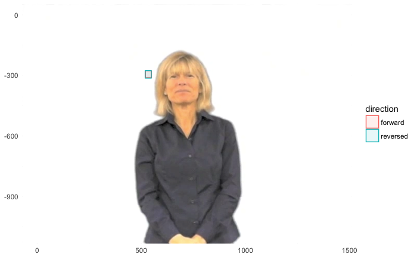

```r
# In this order, we'll get a grand median by taking a participant's median across their 4 stories, than the median for forward and reverse across all participants.
medians <- iqr %>%
  group_by(participant,direction) %>%
  summarise(xIQR = median(xIQR,na.rm=TRUE),
                   yIQR = median(yIQR,na.rm=TRUE),
                   xmed = median(xmed,na.rm=TRUE),
                   ymed = median(ymed,na.rm=TRUE)) %>%
  group_by(direction) %>%
  summarise(xIQR = median(xIQR,na.rm=TRUE),
                   yIQR = median(yIQR,na.rm=TRUE),
                   x = median(xmed,na.rm=TRUE),
                   y = median(ymed,na.rm=TRUE))
medians <- medians %>%
  mutate(y = y*-1,
         xmin = x-(xIQR/2),
         xmax = x+(xIQR/2),
         ymin = y-(yIQR/2),
         ymax = y+(yIQR/2))
img <- readPNG("cindy.png")
g <- rasterGrob(img, interpolate=TRUE, width=unit(1,"npc"), height=unit(1,"npc"))
ggplot(medians, aes(fill=direction,color=direction)) +
  annotation_custom(g, xmin=-Inf, xmax=Inf, ymin=-Inf, ymax=Inf) +
  geom_rect(aes(xmin=xmin,ymin=ymin,xmax=xmax,ymax=ymax),alpha=.1) +
  theme_minimal() + xlim(0,1440) + ylim(-1080,0)
```

```r
# ggplot(iqr.global, aes(fill=direction,color=direction)) +
#   annotation_custom(g, xmin=-Inf, xmax=Inf, ymin=-Inf, ymax=Inf) +
#   geom_rect(aes(xmin=xmin,ymin=ymin,xmax=xmax,ymax=ymax),alpha=.1) +
#   theme_minimal() + xlim(0,1440) + ylim(-1080,0) +
#   geom_hline(yintercept=-1080+885) +
#   geom_hline(yintercept=-1080+525) +
#   annotate(geom="text", x = 300, y = -1080+555, label = "upper shoulder point") +
#   annotate(geom="point", x = 535, y = -1080+525) +
#   annotate(geom="text", x = 535, y = -1080+910, label = "height line") +
#   annotate(geom="rect", xmin = 535, xmax = 535+365, ymin = -525-551, ymax = -1080+525, fill="maroon", color="black", alpha=0.5) +
#   annotate(geom="text", x = 700, y = -900, label = "torso")
```

# Viewing Space Charts for Individuals

Now let’s see the variation in viewing spaces for all our individuals. Should be fun.

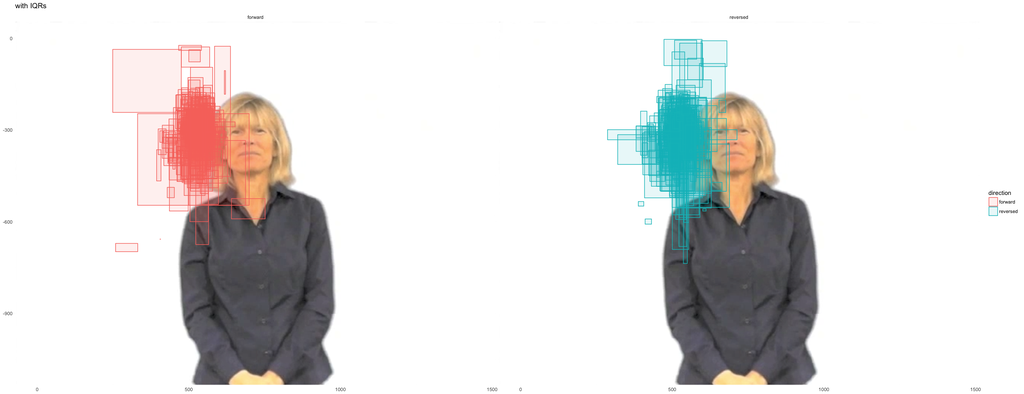

```r
iqr.individuals <- iqr %>%
  rename(x = xmed,
         y = ymed) %>%
  mutate(y = y*-1,
         xmin = x-(xIQR/2),
         xmax = x+(xIQR/2),
         ymin = y-(yIQR/2),
         ymax = y+(yIQR/2))
ggplot(iqr.individuals, aes(fill=direction,color=direction)) +
  annotation_custom(g, xmin=-Inf, xmax=Inf, ymin=-Inf, ymax=Inf) +
  geom_rect(aes(xmin=xmin,ymin=ymin,xmax=xmax,ymax=ymax),alpha=.1) +
  theme_minimal() + xlim(0,1440) + ylim(-1080,0) + facet_wrap("direction") +
  ggtitle("with IQRs")
```

Now let’s make Outer Limits charts which is IQR +/- 2 SDs. But I want to change that because I don’t like the idea of mixing IQRs and SDs.

```r
# sd.individuals <- select(sd.individuals,participant,media,xsd,ysd)
# iqrsd.individuals <- left_join(iqr.individuals,sd.individuals,by=c("participant","media")) %>%
#   mutate(xmin = xmin-(2*xsd),
#          xmax = xmax+(2*xsd),
#          ymin = ymin-(2*ysd),
#          ymax = ymax+(2*ysd))
#
# ggplot(iqrsd.individuals, aes(fill=direction,color=direction)) +
#   annotation_custom(g, xmin=-Inf, xmax=Inf, ymin=-Inf, ymax=Inf) +
#   geom_rect(aes(xmin=xmin,ymin=ymin,xmax=xmax,ymax=ymax),alpha=.1) +
#   theme_minimal() + xlim(0,1440) + ylim(-1080,0) + facet_wrap("direction") +
#   ggtitle("with SDs")
```

```r
# iqrsd.individuals <- iqrsd.individuals %>%
#   group_by(direction) %>%
#   dplyr::summarize(x = mean(x,na.rm=TRUE),
#             y = mean(y,na.rm=TRUE),
#             xmin = mean(xmin,na.rm=TRUE),
#             ymin = mean(ymin,na.rm=TRUE),
#             xmax = mean(xmax,na.rm=TRUE),
#             ymax = mean(ymax,na.rm=TRUE))
# ggplot(iqrsd.individuals, aes(fill=direction,color=direction)) +
#   annotation_custom(g, xmin=-Inf, xmax=Inf, ymin=-Inf, ymax=Inf) +
#   geom_rect(aes(xmin=xmin,ymin=ymin,xmax=xmax,ymax=ymax),alpha=.1) +
#   theme_minimal() + xlim(0,1440) + ylim(-1080,0) + facet_wrap("direction") +
#   ggtitle("Average of above chart (rain's outer limits)")
```

# Within-Subject Variation

Just read [this good post](https://mvuorre.github.io/post/2017/within-subject-scatter/) about plotting within-subject variation and saw it can really apply to this dataset. So I’m going to try out one example.

We know the y means aren’t significantly different across groups but that’s been hard to visualize on a per-subject basis (or even from an error bar chart since the error bars are so small). Let’s visualize that!

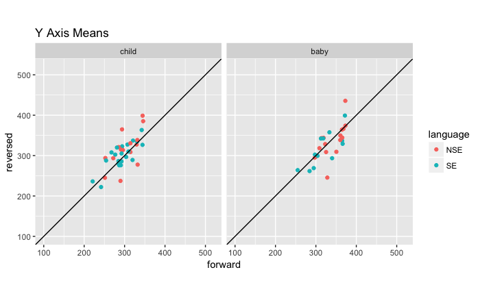

```r
# First get the mean of each trial, THEN the participant-level means
within_subjects <- data %>%
  group_by(participant, agegroup, language, direction, trial) %>%
  summarise(y = mean(y, na.rm = TRUE),
            count = n()) %>%
  group_by(participant, agegroup, language, direction) %>%
  summarise(mean = mean(y, na.rm = TRUE),
            se = sd(y, na.rm = TRUE)/sqrt(n()),
            count = n())
# Then spread out mean and SE columns by direction
within_subjects_means <- within_subjects %>%
  select(-se, -count) %>%
  spread(direction, mean, sep = "_")
within_subjects_se <- within_subjects %>%
  select(-mean, -count) %>%
  spread(direction, se, sep = "SE")
within_subjects <- left_join(within_subjects_means, within_subjects_se)
# Now let's plot just the means
lims <- c(min(data$y, na.rm = T)+100, max(data$y, na.rm = T)-200)
within_subjects %>%
  ggplot(aes(x = direction_forward, y = direction_reversed, color = language)) +
  geom_point() +
  geom_abline() +
  theme(aspect.ratio = 1) +
  scale_x_continuous("forward", limits = lims) +
  scale_y_continuous("reversed", limits = lims) +
  ggtitle("Y Axis Means") +
  facet_wrap("agegroup")
```

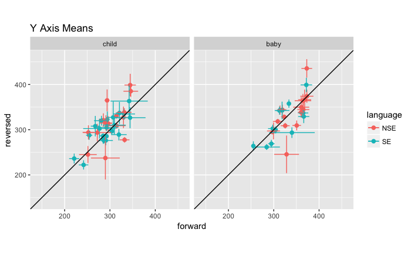

```r
# now with error bars
within_subjects %>%
  ggplot(aes(x = direction_forward, y = direction_reversed, color = language)) +
  geom_point(size = 2) +
  geom_errorbar(aes(ymin=direction_reversed-directionSEreversed, ymax=direction_reversed+directionSEreversed)) +
  geom_errorbarh(aes(xmin=direction_forward-directionSEforward, xmax=direction_forward+directionSEforward)) +
  geom_abline() +
  theme(aspect.ratio = 1) +
  scale_x_continuous("forward", limits = c(140,460)) +
  scale_y_continuous("reversed", limits = c(140,460)) +
  ggtitle("Y Axis Means") +
  facet_wrap("agegroup")
```